# Comorbidity Mappings

Michael Gao

July 8, 2016

# Comorbidity Map Descriptions

The eight mappings (four for ICD-9-CM and four for ICD-10-CM) which we can use readily are the following:

- Elixhauser ICD-9-CM
- Elixhauser ICD-10-CM
- AHRQ ICD-9-CM
- AHRQ ICD-10-CM
- Quan-Elixhauser ICD-9-CM
- Quan-Elixhauser ICD-10-CM
- Quan-Deyo ICD-9-CM
- Quan-Deyo ICD-10-CM

## Elixhauser and Variants

### Elixhauser ICD-9

The original Elixhauser (ICD-9-CM) comorbidities were described in the following: [Elixhauser et al. 1998](http://www.ncbi.nlm.nih.gov/pubmed/9431328) and contains 31 disease categories.

#### Note

Since the original release of icd-9-CM, there have been annual updates, which are published [here](https://www.cms.gov/Medicare/Coding/ICD9ProviderDiagnosticCodes/codes.html). Therefore, the original Elixhauser mapping may not be entirely appropriate for the current implementation of icd-9-CM.

### AHRQ ICD-9

In order to keep the Elixhauser comorbidity mappings up to date, the AHRQ published their own version of the original Elixhauser comorbdity mappings, but updated annually and written in SAS. The documentation can be found [here](http://www.hcup-us.ahrq.gov/toolssoftware/comorbidity/comorbidity.jsp). The disease groupings are exactly the same as the Elixhauser except for the removal of the Arrhythmia grouping, which was done for reliability purposes. ([source](https://www.hcup-us.ahrq.gov/tech_assist/faq.jsp))

### AHRQ ICD-10

The ICD-10-CM version of the AHRQ comorbiditiy mapping (based off of the original Elixhauser mapping) is kept up to date by the AHRQ. The software and documentation for this mapping can be found [here](https://www.hcup-us.ahrq.gov/toolssoftware/ccs10/ccs10.jsp)

### Quan-Elixhauser ICD-9

The Quan-Elixhauser comorbidity mapping was first described in [Quan et al. 2005](http://www.ncbi.nlm.nih.gov/pubmed/16224307). It provided an alternate mapping to the original Elixhauser mappings. However, this has not been updated past the original 2005 version. How much of an impact this has remains to be seen. Supposedly, the Quan-Elixhauser (known as enhanced ICD-9-CM in the Quan et al 2005 paper) algorithm provides better predictive capabilities than the original elixhauser groupings.

### Elixhauser ICD-10

Quan et al. (2005) translated the original Elixhauser et al. (1998) ICD-9 Comorbidity mapping to ICD-10CM codes. These are listed in the Quan et al. paper as simply ICD-10.

### Quan-Elixhauser ICD-10

The Quan-Elixhauser enhanced ICD-10-CM comorbidity mapping was a bit harder to track down, but the source code has been made available at the MCHP - University of Manitoba. The logic can be found [here](http://mchp-appserv.cpe.umanitoba.ca/Upload/SAS/ICD10_EX.sas.txt): This seems to have been a part of the same project as the 2005 paper by Quan, but was never explicitly shown in the original paper.

## Quan-Deyo

The Quan-Deyo comorbidity mappings are based off of the Charlson Comorbidity Index. The original Charlson Comorbidity Index consisted of 19 disease categories, but this was changed to 17 in a subsequent publication by Deyo.

[Charlson et al. 1987](http://www.ncbi.nlm.nih.gov/pubmed/3558716)

[Deyo et al. 1992](http://www.ncbi.nlm.nih.gov/pubmed/1607900)

# Mappings

### Table 1 from Quan et al. 2005

The following table contains comparisons of the following comorbidity mappings:

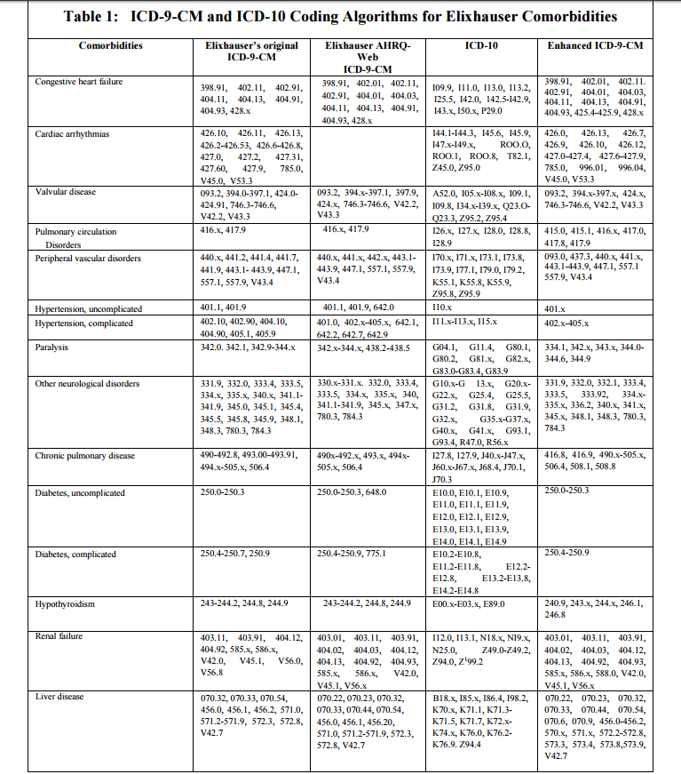

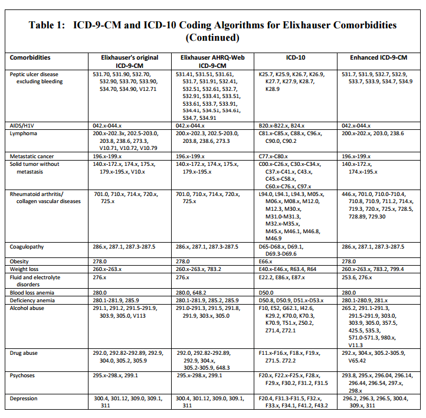

### Quan-Deyo groupings

```r
str(icd_names_charlson)
```

```
## List of 17
##  $ 01: chr "Myocardial Infarction"
##  $ 02: chr "Congestive Heart Failure"
##  $ 03: chr "Periphral Vascular Disease"
##  $ 04: chr "Cerebrovascular Disease"
##  $ 05: chr "Dementia"
##  $ 06: chr "Chronic Pulmonary Disease"
##  $ 07: chr "Connective Tissue Disease-Rheumatic Disease"
##  $ 08: chr "Peptic Ulcer Disease"
##  $ 09: chr "Mild Liver Disease"
##  $ 10: chr "Diabetes without complications"
##  $ 11: chr "Diabetes with complications"
##  $ 12: chr "Paraplegia and Hemiplegia"
##  $ 13: chr "Renal Disease"
##  $ 14: chr "Cancer"
##  $ 15: chr "Moderate or Severe Liver Disease"
##  $ 16: chr "Metastatic Carcinoma"
##  $ 17: chr "HIV/AIDS"
```

```r
str(icd9_map_quan_deyo)
```

```
## List of 17
##  $ MI         :Classes 'icd9', 'character'  atomic [1:222] 410 4100 41000 41001 ...
##   .. ..- attr(*, "icd_short_diag")= logi TRUE
##  $ CHF        :Classes 'icd9', 'character'  atomic [1:176] 39891 40201 40211 40291 ...
##   .. ..- attr(*, "icd_short_diag")= logi TRUE
##  $ PVD        :Classes 'icd9', 'character'  atomic [1:332] 0930 09300 09301 09302 ...
##   .. ..- attr(*, "icd_short_diag")= logi TRUE
##  $ Stroke     :Classes 'icd9', 'character'  atomic [1:1000] 36234 430 4300 43000 ...
##   .. ..- attr(*, "icd_short_diag")= logi TRUE
##  $ Dementia   :Classes 'icd9', 'character'  atomic [1:133] 290 2900 29000 29001 ...
##   .. ..- attr(*, "icd_short_diag")= logi TRUE
##  $ Pulmonary  :Classes 'icd9', 'character'  atomic [1:1498] 4168 41680 41681 41682 ...
##   .. ..- attr(*, "icd_short_diag")= logi TRUE
##  $ Rheumatic  :Classes 'icd9', 'character'  atomic [1:221] 4465 44650 44651 44652 ...
##   .. ..- attr(*, "icd_short_diag")= logi TRUE
##  $ PUD        :Classes 'icd9', 'character'  atomic [1:444] 531 5310 53100 53101 ...
##   .. ..- attr(*, "icd_short_diag")= logi TRUE
##  $ LiverMild  :Classes 'icd9', 'character'  atomic [1:305] 07022 07023 07032 07033 ...
##   .. ..- attr(*, "icd_short_diag")= logi TRUE
##  $ DM         :Classes 'icd9', 'character'  atomic [1:66] 2500 25000 25001 25002 ...
##   .. ..- attr(*, "icd_short_diag")= logi TRUE
##  $ DMcx       :Classes 'icd9', 'character'  atomic [1:44] 2504 25040 25041 25042 ...
##   .. ..- attr(*, "icd_short_diag")= logi TRUE
##  $ Paralysis  :Classes 'icd9', 'character'  atomic [1:321] 3341 33410 33411 33412 ...
##   .. ..- attr(*, "icd_short_diag")= logi TRUE
##  $ Renal      :Classes 'icd9', 'character'  atomic [1:552] 40301 40311 40391 40402 ...
##   .. ..- attr(*, "icd_short_diag")= logi TRUE
##  $ Cancer     :Classes 'icd9', 'character'  atomic [1:6449] 140 1400 14000 14001 ...
##   .. ..- attr(*, "icd_short_diag")= logi TRUE
##  $ LiverSevere:Classes 'icd9', 'character'  atomic [1:77] 4560 45600 45601 45602 ...
##   .. ..- attr(*, "icd_short_diag")= logi TRUE
##  $ Mets       :Classes 'icd9', 'character'  atomic [1:444] 196 1960 19600 19601 ...
##   .. ..- attr(*, "icd_short_diag")= logi TRUE
##  $ HIV        :Classes 'icd9', 'character'  atomic [1:333] 042 0420 04200 04201 ...
##   .. ..- attr(*, "icd_short_diag")= logi TRUE
##  - attr(*, "icd_short_diag")= logi TRUE
##  - attr(*, "class")= chr [1:3] "icd_comorbidity_map" "icd9" "list"
```

```r
str(icd10_map_quan_deyo)
```

```
## List of 17
##  $ MI         :Classes 'icd10', 'character'  atomic [1:20] I21 I210 I2101 I2102 ...
##   .. ..- attr(*, "icd_short_diag")= logi TRUE
##  $ CHF        :Classes 'icd10', 'character'  atomic [1:31] I099 I110 I130 I132 ...
##   .. ..- attr(*, "icd_short_diag")= logi TRUE
##  $ PVD        :Classes 'icd10', 'character'  atomic [1:331] I70 I700 I701 I702 ...
##   .. ..- attr(*, "icd_short_diag")= logi TRUE
##  $ Stroke     :Classes 'icd10', 'character'  atomic [1:461] G45 G450 G451 G452 ...
##   .. ..- attr(*, "icd_short_diag")= logi TRUE
##  $ Dementia   :Classes 'icd10', 'character'  atomic [1:20] F00 F01 F015 F0150 ...
##   .. ..- attr(*, "icd_short_diag")= logi TRUE
##  $ Pulmonary  :Classes 'icd10', 'character'  atomic [1:86] I278 I2781 I2782 I2789 ...
##   .. ..- attr(*, "icd_short_diag")= logi TRUE
##  $ Rheumatic  :Classes 'icd10', 'character'  atomic [1:460] M05 M050 M0500 M0501 ...
##   .. ..- attr(*, "icd_short_diag")= logi TRUE
##  $ PUD        :Classes 'icd10', 'character'  atomic [1:40] K25 K250 K251 K252 ...
##   .. ..- attr(*, "icd_short_diag")= logi TRUE
##  $ LiverMild  :Classes 'icd10', 'character'  atomic [1:46] B18 B180 B181 B182 ...
##   .. ..- attr(*, "icd_short_diag")= logi TRUE
##  $ DM         :Classes 'icd10', 'character'  atomic [1:81] E100 E101 E1010 E1011 ...
##   .. ..- attr(*, "icd_short_diag")= logi TRUE
##  $ DMcx       :Classes 'icd10', 'character'  atomic [1:112] E102 E1021 E1022 E1029 ...
##   .. ..- attr(*, "icd_short_diag")= logi TRUE
##  $ Paralysis  :Classes 'icd10', 'character'  atomic [1:55] G041 G114 G801 G802 ...
##   .. ..- attr(*, "icd_short_diag")= logi TRUE
##  $ Renal      :Classes 'icd10', 'character'  atomic [1:33] I120 I131 I1310 I1311 ...
##   .. ..- attr(*, "icd_short_diag")= logi TRUE
##  $ Cancer     :Classes 'icd10', 'character'  atomic [1:1166] C00 C000 C001 C002 ...
##   .. ..- attr(*, "icd_short_diag")= logi TRUE
##  $ LiverSevere:Classes 'icd10', 'character'  atomic [1:21] I850 I8500 I8501 I859 ...
##   .. ..- attr(*, "icd_short_diag")= logi TRUE
##  $ Mets       :Classes 'icd10', 'character'  atomic [1:62] C77 C770 C771 C772 ...
##   .. ..- attr(*, "icd_short_diag")= logi TRUE
##  $ HIV        :Classes 'icd10', 'character'  atomic [1:4] B20 B21 B22 B24
##   .. ..- attr(*, "icd_short_diag")= logi TRUE
##  - attr(*, "class")= chr [1:2] "icd_comorbidity_map" "list"
```